# ITMD 514 Final Project - Team 7

Jui Dalal, Vikas Sanil

Submitted on 4/27/2022

```r
knitr::opts_chunk$set(
  echo = TRUE,comment = '',
  fig.align = 'center',
  out.width = "70%"
  )
```

```r
library(tidyverse)
```

```r
library(ggplot2)
library(yarrr)
library(gridExtra)
library(MASS)
library(MLmetrics)
require(ISLR)
#library(scales)
```

# Introduction:

We have selected Seoul Bike Sharing Demand Data from UCI Machine Learning Repository for our final Project. Source: URL: https://archive.ics.uci.edu/ml/datasets/Seoul+Bike+Sharing+Demand

Currently Rental bikes are introduced in many urban cities for the enhancement of mobility comfort. It is important to make the rental bike available and accessible to the public at the right time as it lessens the waiting time and promotes mass transport instead of private transport. This is very crucial at present as fossil fuel price are high and earth is warming up faster.

Eventually, providing the city with a stable supply of rental bikes becomes a major concern. The crucial part is the prediction of bike count required at each hour for the stable supply of rental bikes. The dataset contains weather information (Temperature, Humidity, Windspeed, Visibility, Dewpoint, Solar radiation, Snowfall, Rainfall), the number of bikes rented per hour and date information.

# Data Preperation

```r
seoulBikeData<-read.csv(url("https://archive.ics.uci.edu/ml/machine-learning-databases/00560/SeoulBikeData.csv"))
str(seoulBikeData)
```

```
'data.frame':   8760 obs. of  14 variables:
 $ Date                     : chr  "01/12/2017" "01/12/2017" "01/12/2017" "01/12/2017" ...
 $ Rented.Bike.Count        : int  254 204 173 107 78 100 181 460 930 490 ...
 $ Hour                     : int  0 1 2 3 4 5 6 7 8 9 ...
 $ Temperature..C.          : num  -5.2 -5.5 -6 -6.2 -6 -6.4 -6.6 -7.4 -7.6 -6.5 ...
 $ Humidity...              : int  37 38 39 40 36 37 35 38 37 27 ...
 $ Wind.speed..m.s.         : num  2.2 0.8 1 0.9 2.3 1.5 1.3 0.9 1.1 0.5 ...
 $ Visibility..10m.         : int  2000 2000 2000 2000 2000 2000 2000 2000 2000 1928 ...
 $ Dew.point.temperature..C.: num  -17.6 -17.6 -17.7 -17.6 -18.6 -18.7 -19.5 -19.3 -19.8 -22.4 ...
 $ Solar.Radiation..MJ.m2.  : num  0 0 0 0 0 0 0 0 0.01 0.23 ...
 $ Rainfall.mm.             : num  0 0 0 0 0 0 0 0 0 0 ...
 $ Snowfall..cm.            : num  0 0 0 0 0 0 0 0 0 0 ...
 $ Seasons                  : chr  "Winter" "Winter" "Winter" "Winter" ...
 $ Holiday                  : chr  "No Holiday" "No Holiday" "No Holiday" "No Holiday" ...
 $ Functioning.Day          : chr  "Yes" "Yes" "Yes" "Yes" ...
```

```r
seoulBikeData<-mutate(seoulBikeData, Weekday=format(as.Date(Date),"%A"), Date=as.Date(Date, "%d/%m/%Y"))
colnames(seoulBikeData)<-c("Date", "RentedBikeCount", "Hour", "TemperatureC", "Humidity", "WindSpeedms", "Visibility10m", "DewPointTempC", "SolarRadiationMJm2", "Rainfallmm", "Snowfallcm", "Seasons", "Holiday", "FunctioningDay", "Weekday")
str(seoulBikeData)
```

```
'data.frame':   8760 obs. of  15 variables:
 $ Date              : Date, format: "2017-12-01" "2017-12-01" ...
 $ RentedBikeCount   : int  254 204 173 107 78 100 181 460 930 490 ...
 $ Hour              : int  0 1 2 3 4 5 6 7 8 9 ...
 $ TemperatureC      : num  -5.2 -5.5 -6 -6.2 -6 -6.4 -6.6 -7.4 -7.6 -6.5 ...
 $ Humidity          : int  37 38 39 40 36 37 35 38 37 27 ...
 $ WindSpeedms       : num  2.2 0.8 1 0.9 2.3 1.5 1.3 0.9 1.1 0.5 ...
 $ Visibility10m     : int  2000 2000 2000 2000 2000 2000 2000 2000 2000 1928 ...
 $ DewPointTempC     : num  -17.6 -17.6 -17.7 -17.6 -18.6 -18.7 -19.5 -19.3 -19.8 -22.4 ...
 $ SolarRadiationMJm2: num  0 0 0 0 0 0 0 0 0.01 0.23 ...
 $ Rainfallmm        : num  0 0 0 0 0 0 0 0 0 0 ...
 $ Snowfallcm        : num  0 0 0 0 0 0 0 0 0 0 ...
 $ Seasons           : chr  "Winter" "Winter" "Winter" "Winter" ...
 $ Holiday           : chr  "No Holiday" "No Holiday" "No Holiday" "No Holiday" ...
 $ FunctioningDay    : chr  "Yes" "Yes" "Yes" "Yes" ...
 $ Weekday           : chr  "Thursday" "Thursday" "Thursday" "Thursday" ...
```

```r
dimensionNames<-c("Observation", "Attributes")
dimensionValues<-dim(seoulBikeData)
dimension<-matrix(data=c(dimensionNames,dimensionValues), nrow=2, ncol = 2)
missingValues<-sum(is.na(seoulBikeData))
duplicatedValues<-sum(duplicated(seoulBikeData))
summary(seoulBikeData)
```

```
      Date            RentedBikeCount       Hour        TemperatureC
 Min.   :2017-12-01   Min.   :   0.0   Min.   : 0.00   Min.   :-17.80
 1st Qu.:2018-03-02   1st Qu.: 191.0   1st Qu.: 5.75   1st Qu.:  3.50
 Median :2018-06-01   Median : 504.5   Median :11.50   Median : 13.70
 Mean   :2018-06-01   Mean   : 704.6   Mean   :11.50   Mean   : 12.88
 3rd Qu.:2018-08-31   3rd Qu.:1065.2   3rd Qu.:17.25   3rd Qu.: 22.50
 Max.   :2018-11-30   Max.   :3556.0   Max.   :23.00   Max.   : 39.40
    Humidity      WindSpeedms    Visibility10m  DewPointTempC
 Min.   : 0.00   Min.   :0.000   Min.   :  27   Min.   :-30.600
 1st Qu.:42.00   1st Qu.:0.900   1st Qu.: 940   1st Qu.: -4.700
 Median :57.00   Median :1.500   Median :1698   Median :  5.100
 Mean   :58.23   Mean   :1.725   Mean   :1437   Mean   :  4.074
 3rd Qu.:74.00   3rd Qu.:2.300   3rd Qu.:2000   3rd Qu.: 14.800
 Max.   :98.00   Max.   :7.400   Max.   :2000   Max.   : 27.200
 SolarRadiationMJm2   Rainfallmm        Snowfallcm        Seasons
 Min.   :0.0000     Min.   : 0.0000   Min.   :0.00000   Length:8760
 1st Qu.:0.0000     1st Qu.: 0.0000   1st Qu.:0.00000   Class :character
 Median :0.0100     Median : 0.0000   Median :0.00000   Mode  :character
 Mean   :0.5691     Mean   : 0.1487   Mean   :0.07507
 3rd Qu.:0.9300     3rd Qu.: 0.0000   3rd Qu.:0.00000
 Max.   :3.5200     Max.   :35.0000   Max.   :8.80000
   Holiday          FunctioningDay       Weekday
 Length:8760        Length:8760        Length:8760
 Class :character   Class :character   Class :character
 Mode  :character   Mode  :character   Mode  :character
```

```r
holidaySeoulBikeRented<-seoulBikeData[seoulBikeData$Holiday=="Holiday",]
noHolidaySeoulBikeRented<-seoulBikeData[seoulBikeData$Holiday=="No Holiday",]
funcDaySeoulBikeRented<-seoulBikeData[seoulBikeData$FunctioningDay=="Yes",]
nonFuncSeoulBikeRented<-seoulBikeData[seoulBikeData$FunctioningDay=="No",]
holidayDate<- unique(holidaySeoulBikeRented$Date)
```

## Output of data preperation

| Observation | 8760 |
| --- | --- |
| Attributes | 15 |

Number of Missing values 0.  
Number of duplicated value 0.

We are considering $RentedBikeCount$ as our $response/output$ in Seoul Bike Sharing Demand data set.

# Data Exploration:

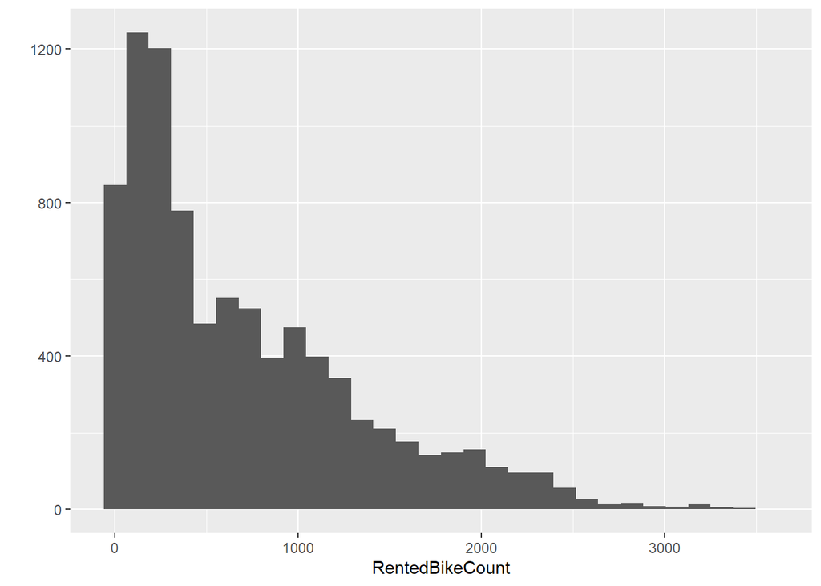

```r
qplot(RentedBikeCount, data=seoulBikeData, bins=30)
```

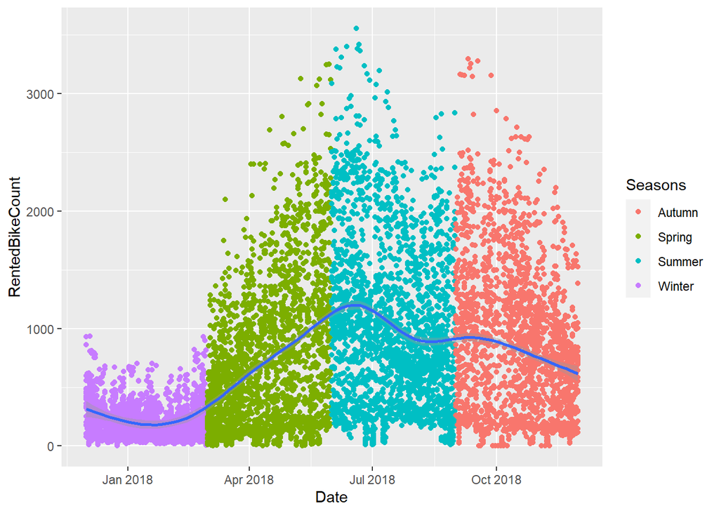

```r
ggplot(data = seoulBikeData) +
  geom_point(mapping = aes(x = Date, y = RentedBikeCount,colour = Seasons))+
  geom_smooth(mapping = aes(x = Date, y = RentedBikeCount))
```

- This graph represents the Rental Bike counts compared against Date with Seasons colored. As we see here the plots are almost normal from April to October. It shows there is a high amount of Bikes Rented out in summer/ during June-July compared to January. As we can see January has a low count due to winter or snow. Whereas counts for Spring, Summer, and Fall are distributed normally because of high demand with good weather.

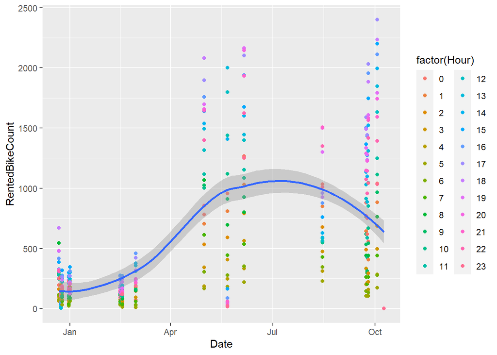

```r
ggplot(data = holidaySeoulBikeRented) +
  geom_point(mapping = aes(x = Date, y = RentedBikeCount,colour = factor(Hour)))+
  geom_smooth(mapping = aes(x = Date, y = RentedBikeCount))
```

```r
knitr::kable(holidayDate)
```

| x |
| --- |
| 2017-12-22 |
| 2017-12-24 |
| 2017-12-25 |
| 2017-12-31 |
| 2018-01-01 |
| 2018-02-15 |
| 2018-02-16 |
| 2018-02-17 |
| 2018-03-01 |
| 2018-05-01 |
| 2018-05-22 |
| 2018-06-06 |
| 2018-08-15 |
| 2018-09-23 |
| 2018-09-24 |
| 2018-09-25 |
| 2018-10-03 |
| 2018-10-09 |

-⦁ Holiday Rented Bike: This graph shows the count of rental bikes on Holidays. During the holidays Autumn season has a max count of bike rentals, Average count of bike rentals in Spring and Summer while during the winter it has very few counts.

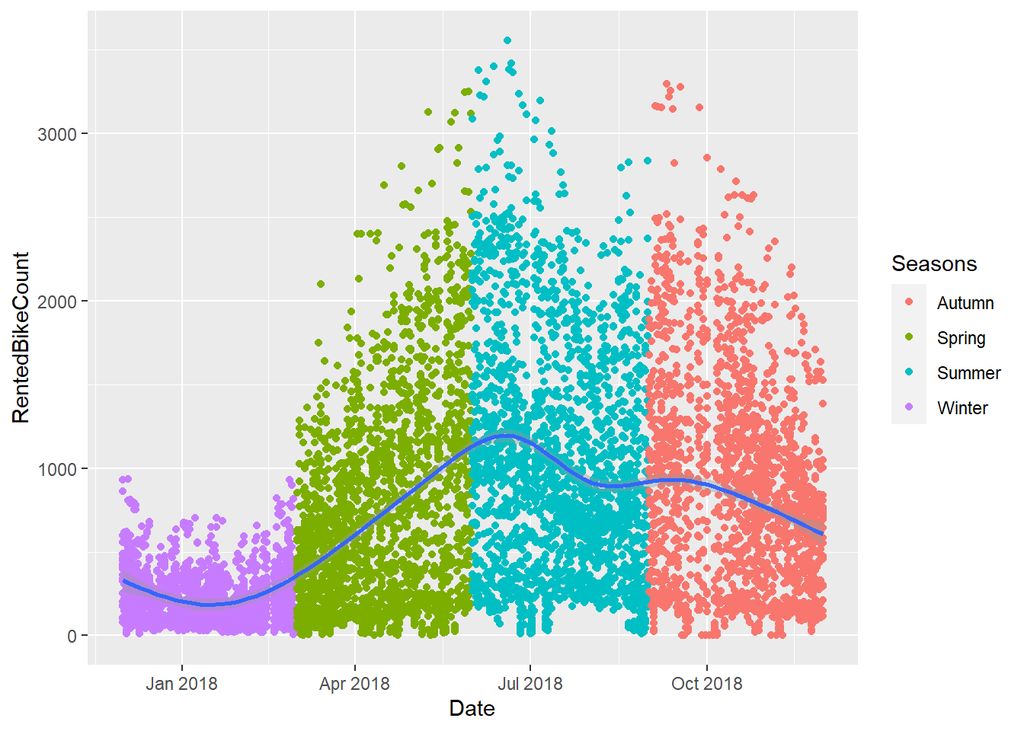

```r
ggplot(data = noHolidaySeoulBikeRented) +
  geom_point(mapping = aes(x = Date, y = RentedBikeCount,colour = Seasons))+
  geom_smooth(mapping = aes(x = Date, y = RentedBikeCount))
```

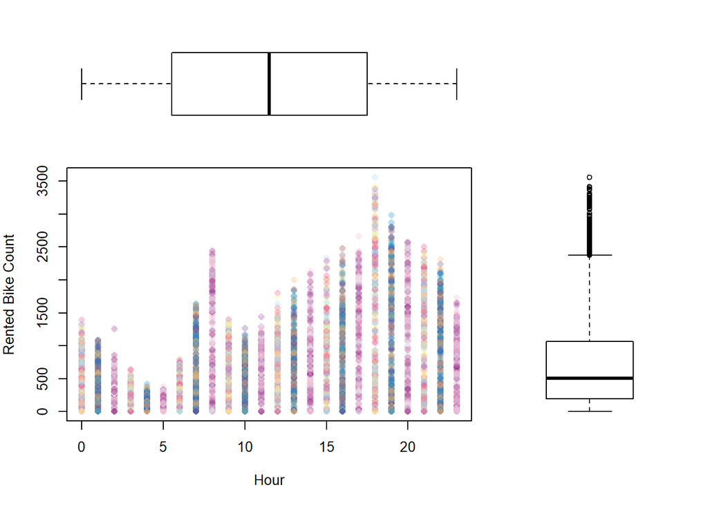

```r
# Plot 7
layout(mat = matrix(c(2, 1, 0, 3),
                        nrow = 2,
                        ncol = 2),
       heights = c(1, 2),    # Heights of the two rows
       widths = c(2, 1))     # Widths of the two columns

# Sub Plot 1: Scatterplot
par(mar = c(5, 4, 0, 0))
plot(x = seoulBikeData$Hour,
     y = seoulBikeData$RentedBikeCount,
     xlab = "Hour",
     ylab = "Rented Bike Count",
     pch = 16,
     col = yarrr::piratepal("pony", trans = .7))

# Sub Plot 2: Top (height) boxplot
par(mar = c(0, 4, 0, 0))
boxplot(seoulBikeData$Hour, xaxt = "n",
        yaxt = "n", bty = "n",
        col = "white", frame = FALSE, horizontal = TRUE)

# Sub Plot 3: Right (weight) boxplot
par(mar = c(5, 0, 0, 0))
boxplot(seoulBikeData$RentedBikeCount, xaxt = "n",
        yaxt = "n", bty = "n",
        col = "white", frame = FALSE)
```

```r
print("Source: https://bookdown.org/ndphillips/YaRrr/arranging-plots-with-parmfrow-and-layout.html")
```

```
[1] "Source: https://bookdown.org/ndphillips/YaRrr/arranging-plots-with-parmfrow-and-layout.html"
```

> In the Scatter plot, it shows how many bikes are rented hourly. As it shows the bikes rented are higher in the evening compared with the early morning. The reason is where the people would like to enjoy the evening ride more.

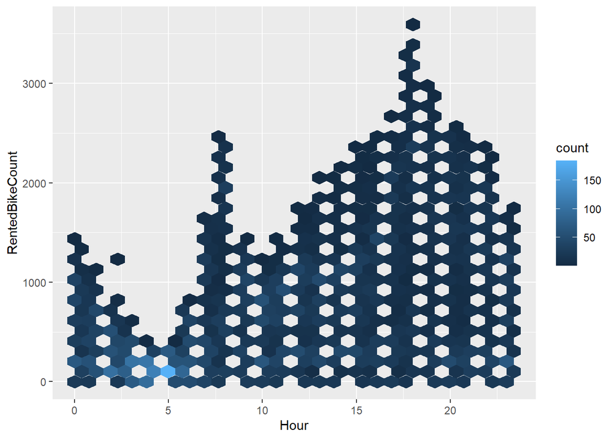

```r
ggplot(seoulBikeData, aes(Hour,RentedBikeCount))+
  geom_hex()
```

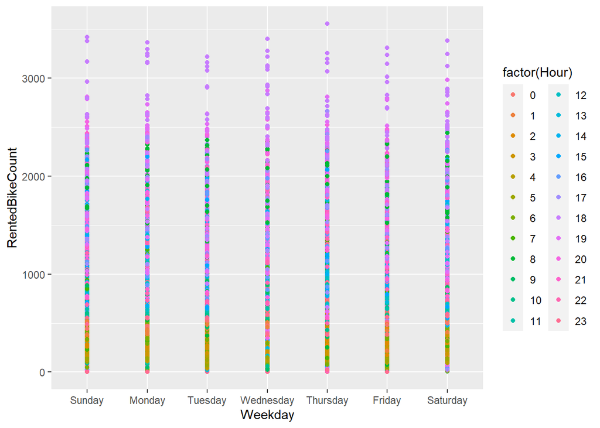

```r
ggplot(data = seoulBikeData, aes(x = Weekday, y = RentedBikeCount)) +
  geom_point(mapping = aes(colour = factor(Hour) ))+
  scale_x_discrete(limits=c("Sunday","Monday","Tuesday", "Wednesday", "Thursday", "Friday", "Saturday"))
```

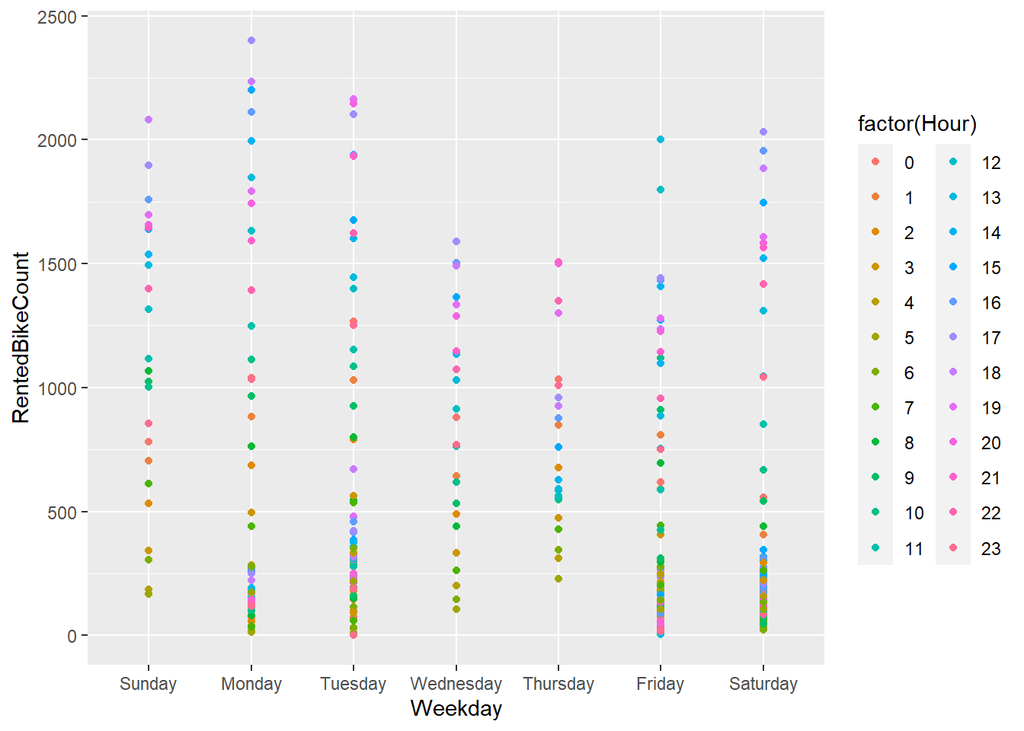

```r
ggplot(data = holidaySeoulBikeRented, aes(x = Weekday, y = RentedBikeCount)) +
  geom_point(mapping = aes(colour = factor(Hour) ))+
  scale_x_discrete(limits=c("Sunday","Monday","Tuesday", "Wednesday", "Thursday", "Friday", "Saturday"))
```

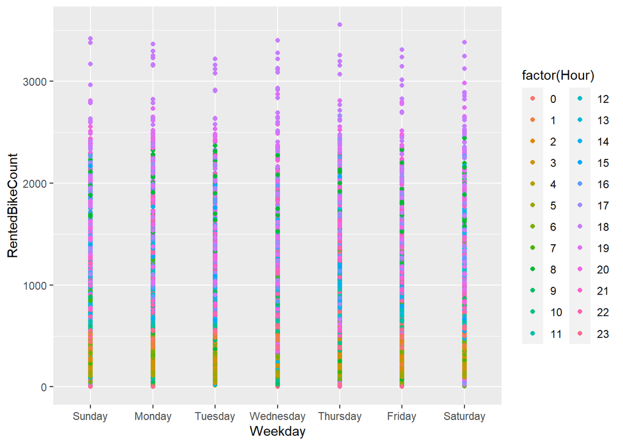

```r
ggplot(data = noHolidaySeoulBikeRented, aes(x = Weekday, y = RentedBikeCount)) +
  geom_point(mapping = aes(colour = factor(Hour) ))+
  scale_x_discrete(limits=c("Sunday","Monday","Tuesday", "Wednesday", "Thursday", "Friday", "Saturday"))
```

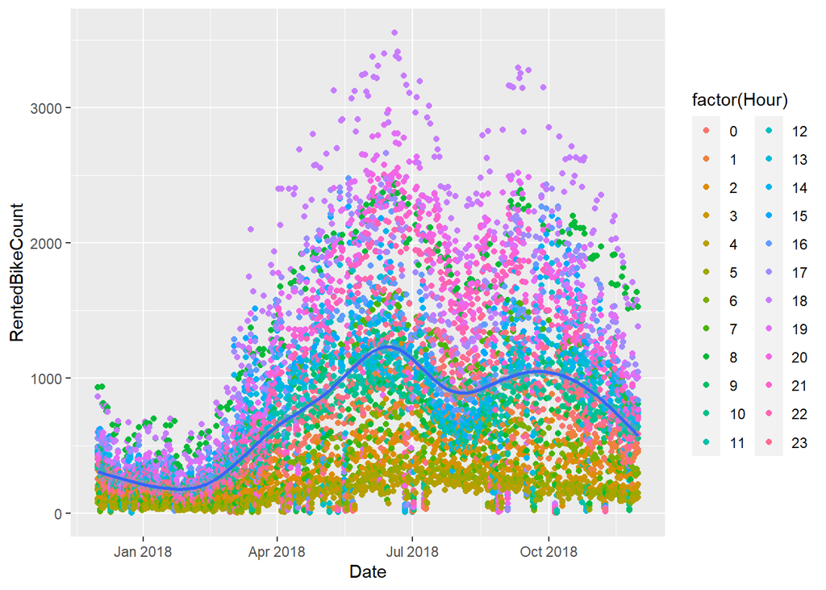

```r
ggplot(data = funcDaySeoulBikeRented) +
  geom_point(mapping = aes(x = Date, y = RentedBikeCount,colour = factor(Hour)))+
  geom_smooth(mapping = aes(x = Date, y = RentedBikeCount))
```

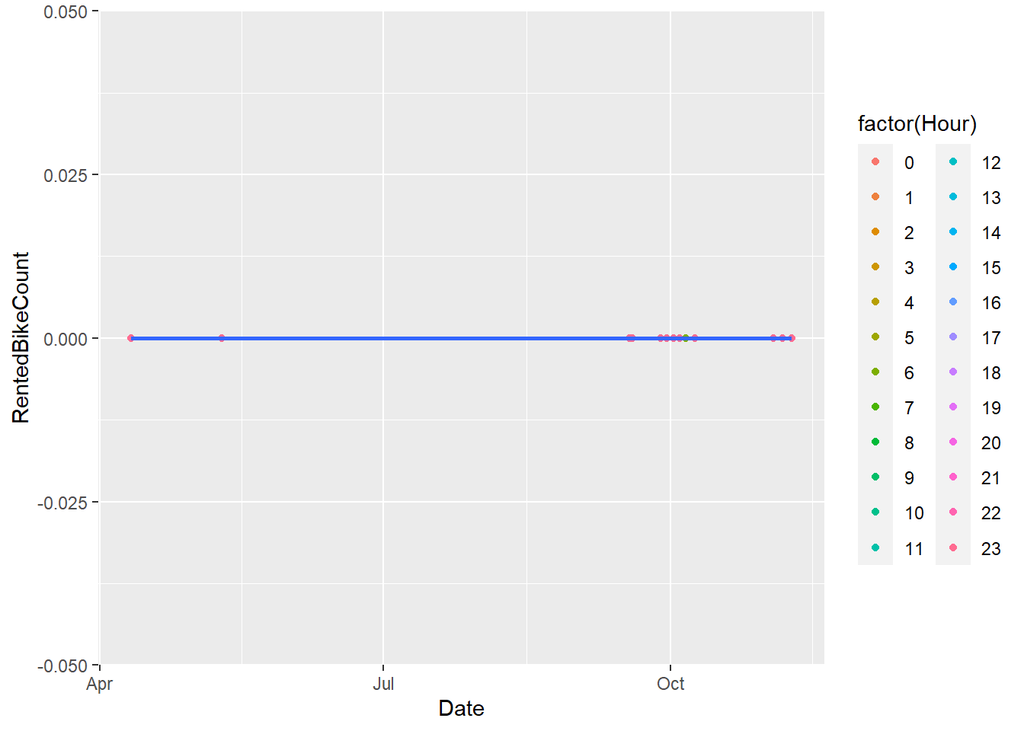

```r
ggplot(data = nonFuncSeoulBikeRented) +
  geom_point(mapping = aes(x = Date, y = RentedBikeCount,colour = factor(Hour)))+
  geom_smooth(mapping = aes(x = Date, y = RentedBikeCount))
```

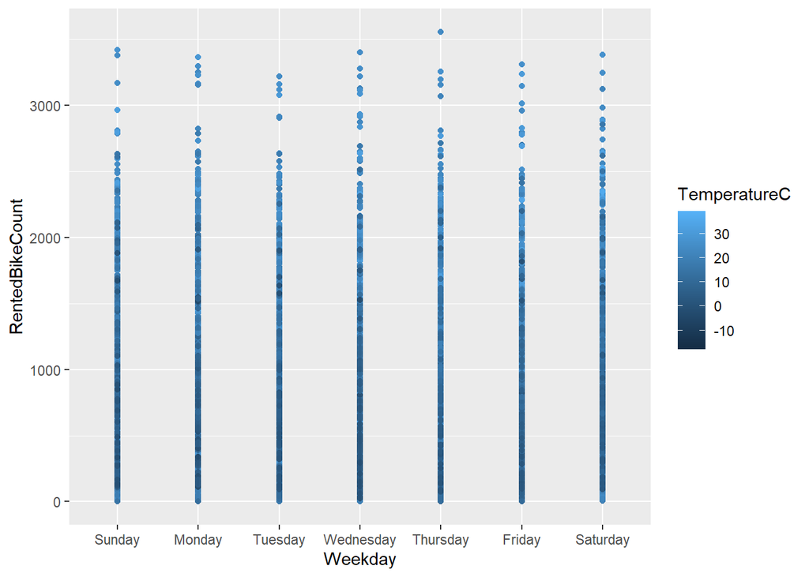

```r
# Plot 7
ggplot(data = seoulBikeData, aes(x = Weekday, y = RentedBikeCount)) +
  geom_point(mapping = aes(colour = TemperatureC))+
  scale_x_discrete(limits=c("Sunday","Monday","Tuesday", "Wednesday", "Thursday", "Friday", "Saturday"))
```

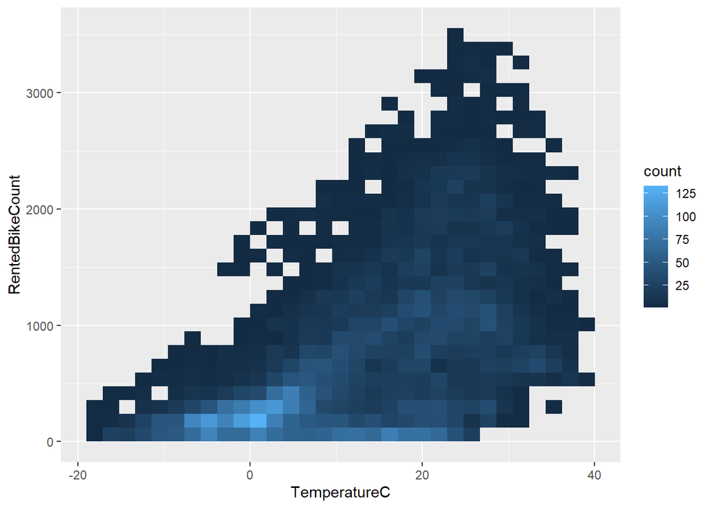

```r
# Plot 8
ggplot(data = seoulBikeData) +
  geom_bin2d(mapping = aes(x = TemperatureC, y = RentedBikeCount))
```

>Above graph represents the count of rental bikes using the temperature on weekdays. As it shows during 30 degree Celsius there are more bikes rented above 2000 counts per week. Whereas during 10 degree Celsius or below, it reduces the count of rental bikes per week.

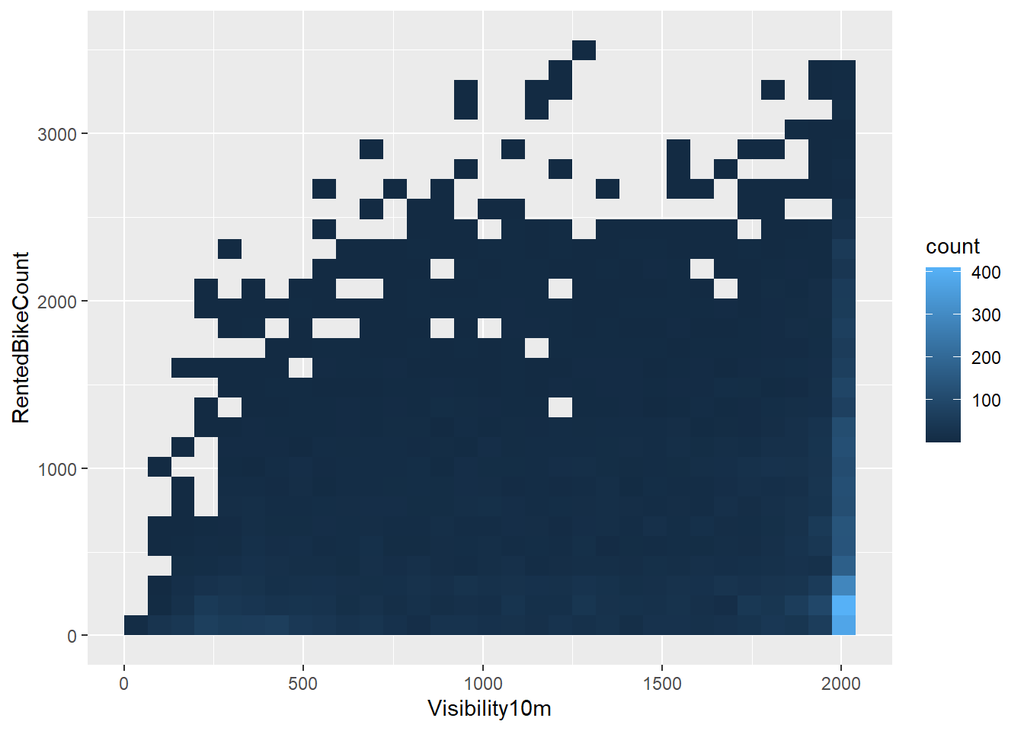

```r
# Plot 9
ggplot(data = seoulBikeData) +
  geom_bin2d(mapping = aes(x = Visibility10m, y = RentedBikeCount))
```

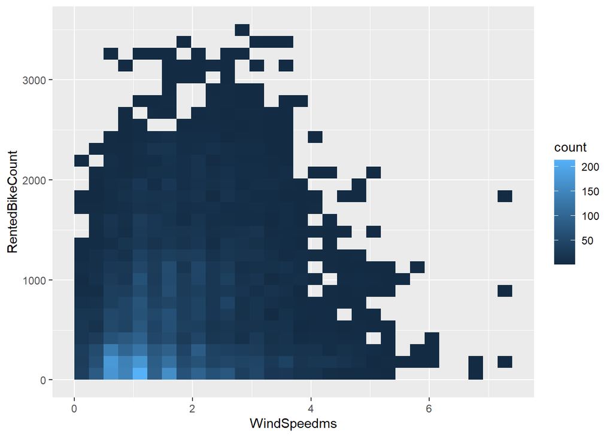

```r
# Plot 10
ggplot(data = seoulBikeData) +
  geom_bin2d(mapping = aes(x = WindSpeedms, y = RentedBikeCount))
```

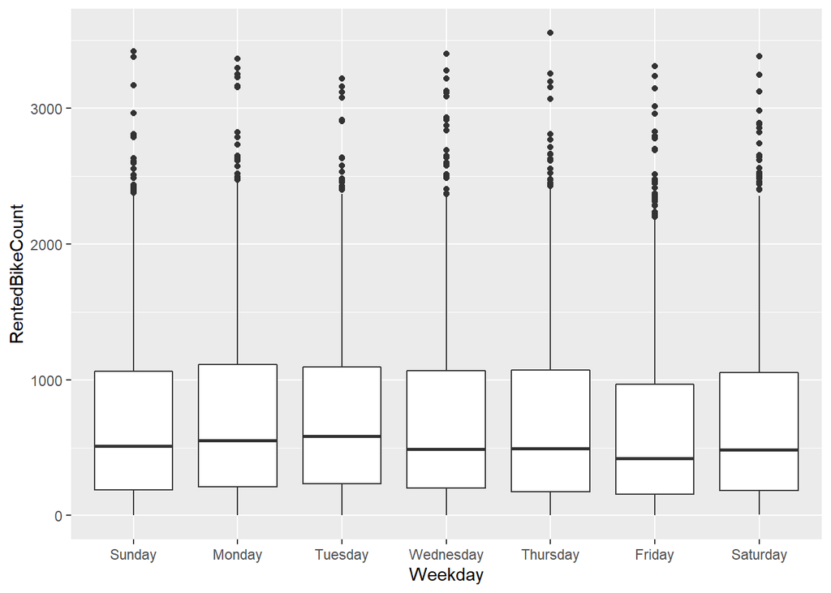

```r
# Plot 12
ggplot(data = seoulBikeData, mapping = aes(x = Weekday , y = RentedBikeCount)) +
  geom_boxplot()+scale_x_discrete(limits=c("Sunday","Monday","Tuesday", "Wednesday", "Thursday", "Friday", "Saturday"))
```

>The above weekly box plot addresses all the days that have almost the same outliers and counts bike rentals.

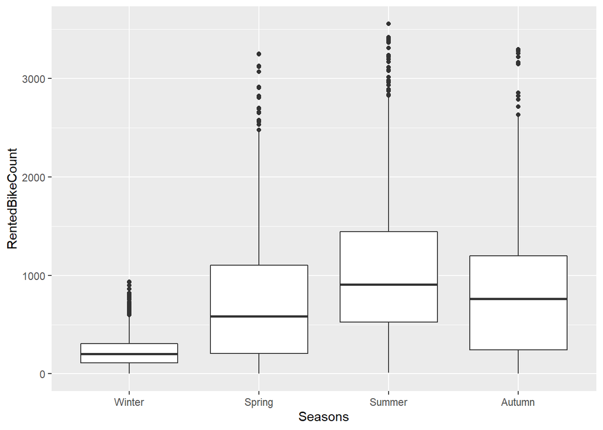

```r
# Plot 13
ggplot(data = seoulBikeData, mapping = aes(x = Seasons, y = RentedBikeCount)) +
  geom_boxplot()+scale_x_discrete(limits=c("Winter","Spring","Summer", "Autumn"))
```

>Boxplot data on how the many bikes rented as per the season. Since there’s a less count of bikes rented in Winter compared to spring, summer, and fall.

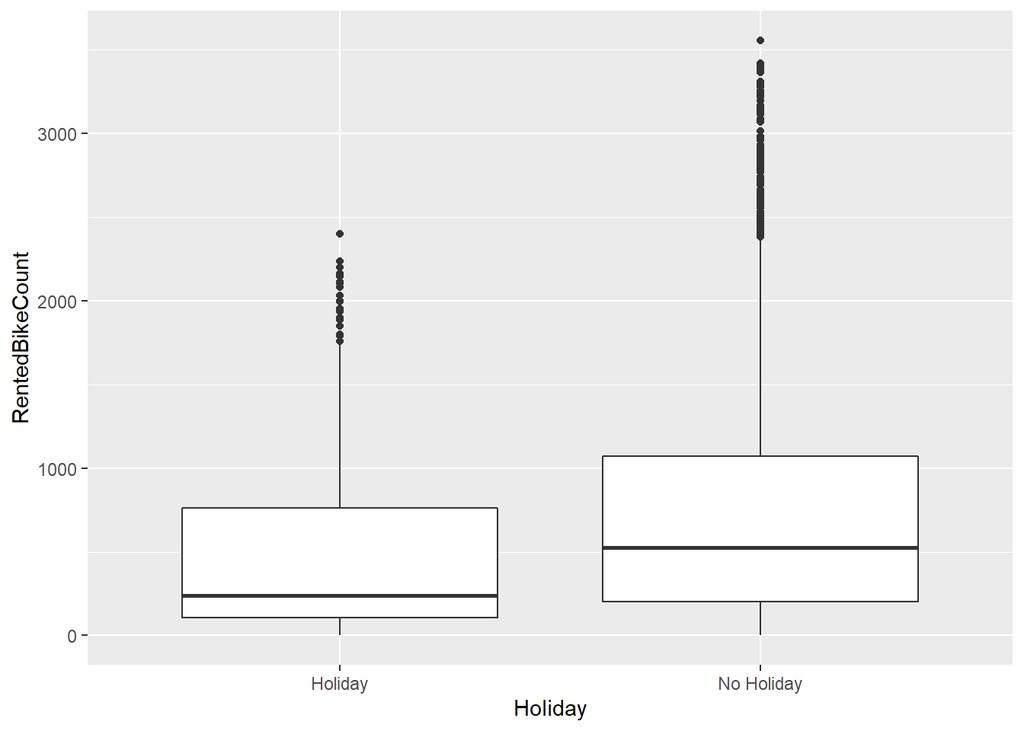

```r
# Plot 14
ggplot(data = seoulBikeData, mapping = aes(x = Holiday, y = RentedBikeCount)) +
  geom_boxplot()
```

>The above graph represents how many bikes are rented on Holiday and No Holiday, since there are more or high count of rental bikes on no Holiday, it shows more outliers on the No holiday or working days while it has low or very few rental bikes count outliers on Holidays.

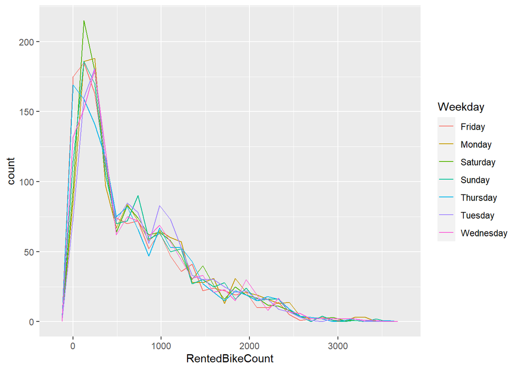

```r
# Plot 15
ggplot(data = seoulBikeData, mapping = aes(x = RentedBikeCount)) +
  geom_freqpoly(mapping = aes(colour = Weekday), bins=30)
```

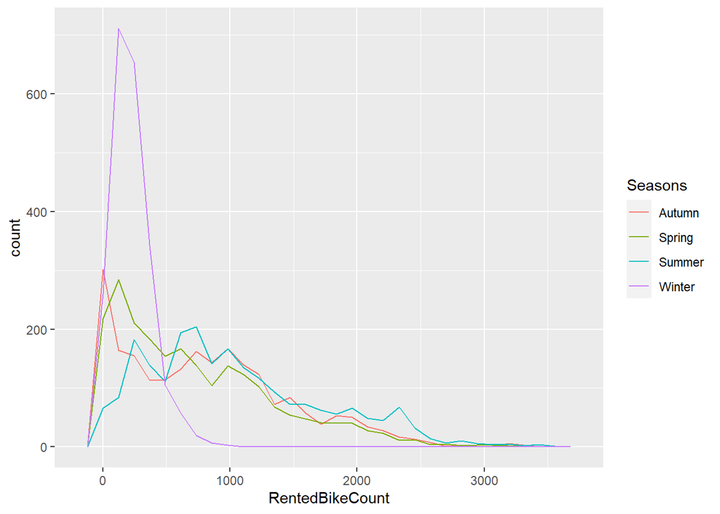

```r
# Plot 16
ggplot(data = seoulBikeData, mapping = aes(x = RentedBikeCount)) +
  geom_freqpoly(mapping = aes(colour = Seasons), bins=30)
```

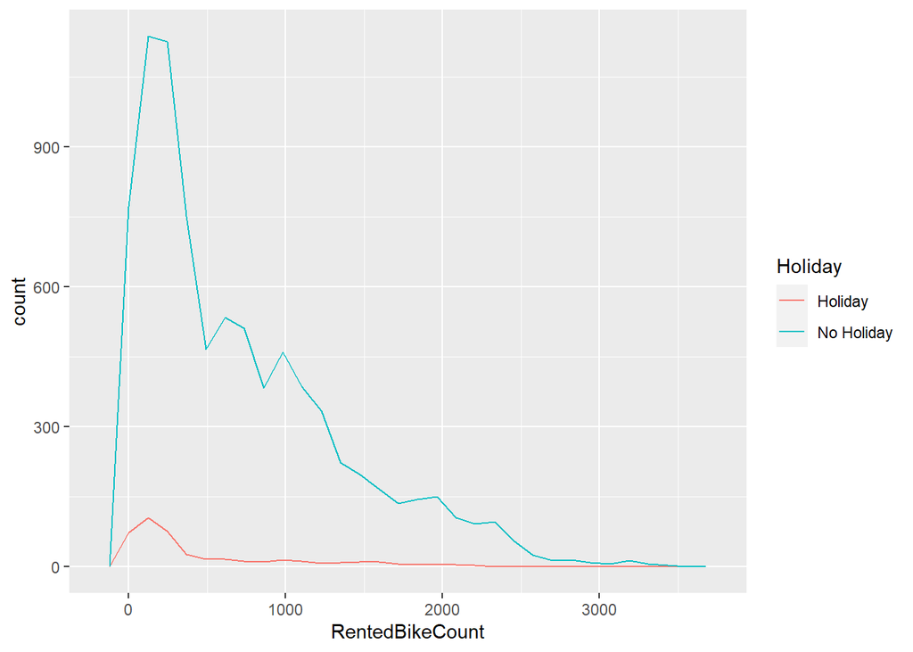

```r
# Plot 17
ggplot(data = seoulBikeData, mapping = aes(x = RentedBikeCount)) +
  geom_freqpoly(mapping = aes(colour = Holiday), bins=30)
```

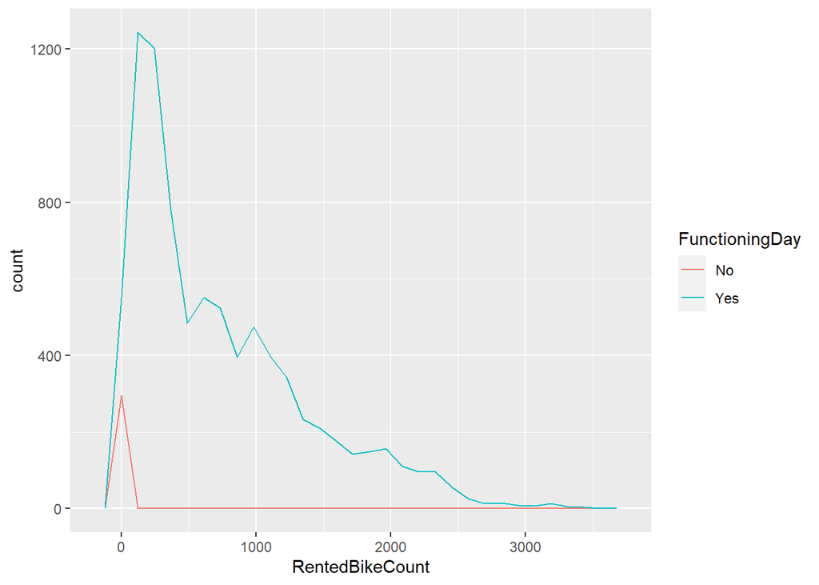

```r
ggplot(data = seoulBikeData, mapping = aes(x = RentedBikeCount)) +
  geom_freqpoly(mapping = aes(colour = FunctioningDay), bins=30)
```

#Data Analysis:

##Hypothesis Testing:

We should use t test to compare mean, as we don’t know the variance. We can conduct an F test first to see if they have the same variance.

```r
var.test(holidaySeoulBikeRented$RentedBikeCount, noHolidaySeoulBikeRented$RentedBikeCount)
```

```
    F test to compare two variances

data:  holidaySeoulBikeRented$RentedBikeCount and noHolidaySeoulBikeRented$RentedBikeCount
F = 0.77854, num df = 431, denom df = 8327, p-value = 0.000601
alternative hypothesis: true ratio of variances is not equal to 1
95 percent confidence interval:
 0.6817284 0.8967561
sample estimates:
ratio of variances
         0.7785387
```

```r
t.test(holidaySeoulBikeRented$RentedBikeCount, noHolidaySeoulBikeRented$RentedBikeCount)
```

```
    Welch Two Sample t-test

data:  holidaySeoulBikeRented$RentedBikeCount and noHolidaySeoulBikeRented$RentedBikeCount
t = -7.5973, df = 490.23, p-value = 1.545e-13
alternative hypothesis: true difference in means is not equal to 0
95 percent confidence interval:
 -271.1960 -159.7461
sample estimates:
mean of x mean of y
 499.7569  715.2280
```

##Regression analysis:

```r
#Simple Linear regression test
fitlm1<-lm(RentedBikeCount~Hour, data=funcDaySeoulBikeRented)
summary(fitlm1)
```

```
Call:
lm(formula = RentedBikeCount ~ Hour, data = funcDaySeoulBikeRented)

Residuals:
     Min       1Q   Median       3Q      Max
-1178.78  -397.80   -99.98   321.63  2570.57

Coefficients:
            Estimate Std. Error t value Pr(>|t|)
(Intercept) 274.9817    12.2613   22.43   <2e-16 ***
Hour         39.4694     0.9131   43.22   <2e-16 ***
---
Signif. codes:  0 '***' 0.001 '**' 0.01 '*' 0.05 '.' 0.1 ' ' 1

Residual standard error: 581.4 on 8463 degrees of freedom
Multiple R-squared:  0.1808,    Adjusted R-squared:  0.1807
F-statistic:  1868 on 1 and 8463 DF,  p-value: < 2.2e-16
```

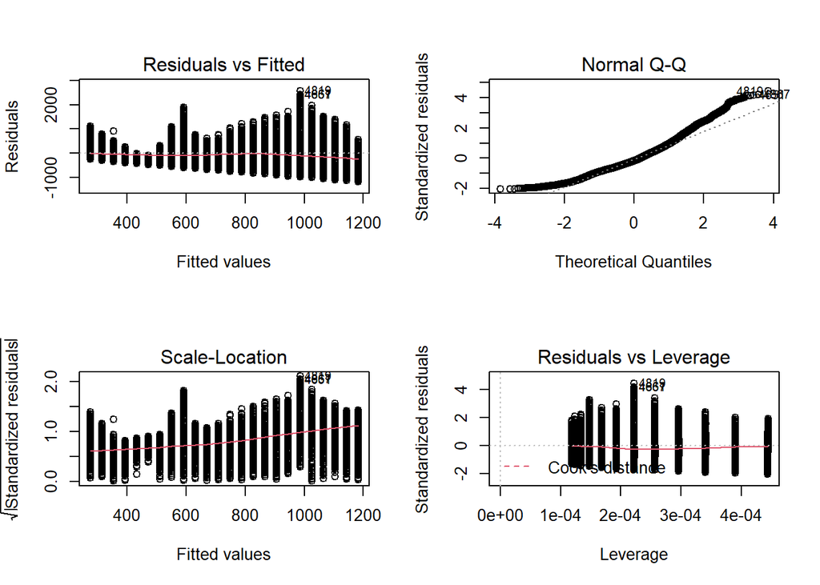

```r
par(mfrow=c(2,2))
plot(fitlm1)
```

```r
#Predicted Rented Bike Count when Hour of the day is 18:00
newHour<-data.frame(Hour = 18)
predict(fitlm1,newHour, interval="confidence")
```

```
       fit      lwr      upr
1 985.4306 968.4447 1002.416
```

```r
predict(fitlm1,newHour, interval="prediction")
```

```
       fit    lwr      upr
1 985.4306 -154.4 2125.261
```

```r
fitlm2<-lm(RentedBikeCount~Date, data=funcDaySeoulBikeRented)
summary(fitlm2)
```

```
Call:
lm(formula = RentedBikeCount ~ Date, data = funcDaySeoulBikeRented)

Residuals:
    Min      1Q  Median      3Q     Max
-1141.2  -367.9  -134.7   265.8  2774.4

Coefficients:
              Estimate Std. Error t value Pr(>|t|)
(Intercept) -4.219e+04  1.083e+03  -38.96   <2e-16 ***
Date         2.428e+00  6.126e-02   39.63   <2e-16 ***
---
Signif. codes:  0 '***' 0.001 '**' 0.01 '*' 0.05 '.' 0.1 ' ' 1

Residual standard error: 590 on 8463 degrees of freedom
Multiple R-squared:  0.1565,    Adjusted R-squared:  0.1564
F-statistic:  1571 on 1 and 8463 DF,  p-value: < 2.2e-16
```

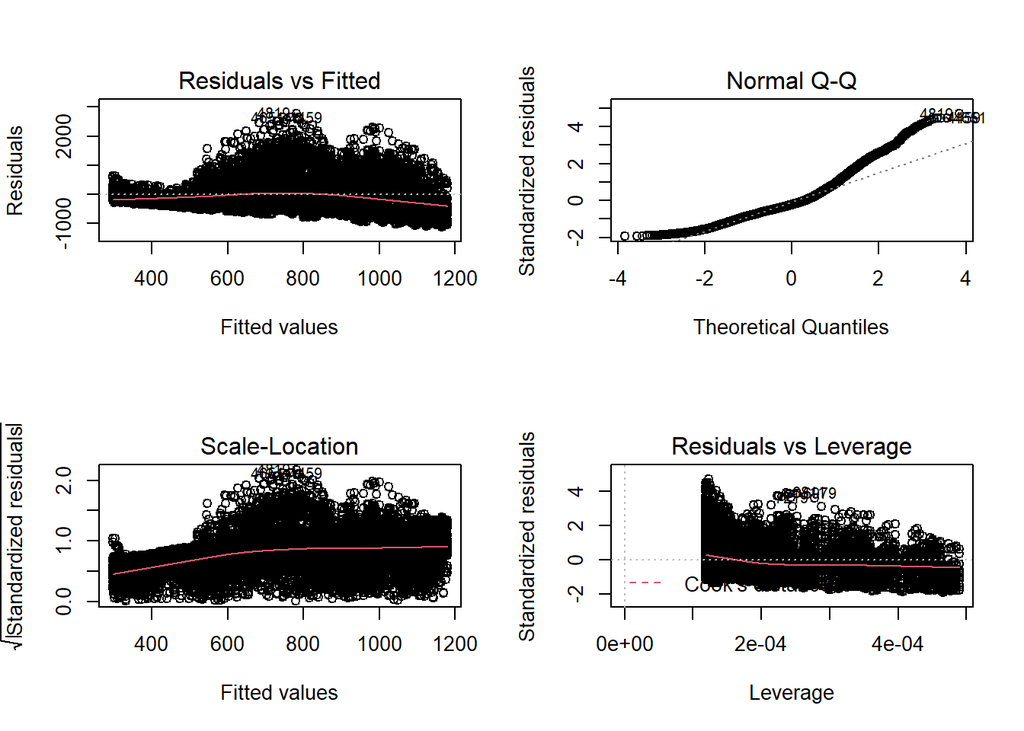

```r
par(mfrow=c(2,2))
plot(fitlm2)
```

```r
#Predicted Rented Bike Count when Date of the day is 05/05/2018
newDate<-data.frame(Date = as.Date("05/05/2018", "%d/%m/%Y"))
predict(fitlm2,newDate, interval="confidence")
```

```
       fit      lwr      upr
1 672.3822 659.5026 685.2619
```

```r
predict(fitlm2,newDate, interval="prediction")
```

```
       fit       lwr      upr
1 672.3822 -484.1779 1828.942
```

```r
#res<-cor(funcDaySeoulBikeRented)
#round(res,2)

#i<-sample(2, nrow(funcDaySeoulBikeRented), replace = TRUE, prob = c(0.8,0.2))
#funcDaySeoulBikeRentedTraining<-funcDaySeoulBikeRented[i==1,]
#funcDaySeoulBikeRentedTest<-funcDaySeoulBikeRented[i==2,]

#Forward Stepwise regression model
#null model
#intercept_only<-lm(RentedBikeCount~ 1, data=funcDaySeoulBikeRentedTraining)
#  full model
#all<-lm(RentedBikeCount~., data = funcDaySeoulBikeRentedTraining)
# forward set-wise regression
#forward<- stepAIC(intercept_only, direction='forward', scope=formula(all))
#results
#forward$anova
#summary(forward)
#MAE and MSE calculation
#ypred_forward<-predict(object = forward, newdata=funcDaySeoulBikeRentedTest)
#MAE(y_pred = ypred_forward, y_true = funcDaySeoulBikeRentedTest$RentedBikeCount)
#MSE(y_pred = ypred_forward, y_true = funcDaySeoulBikeRentedTest$RentedBikeCount)

#Backward Stepwise regression model
#backward<- stepAIC(all, direction='backward')
#results
#backward$anova
#summary(backward)
#MAE and MSE calculation
#ypred_backward<-predict(object = backward, newdata=funcDaySeoulBikeRentedTest)
#MAE(y_pred = ypred_backward, y_true = funcDaySeoulBikeRentedTest$RentedBikeCount)
#MSE(y_pred = ypred_backward, y_true = funcDaySeoulBikeRentedTest$RentedBikeCount)

#Compare Regression Model
#par(mfrow=c(2,2))
#plot(forward)
#par(mfrow=c(2,2))
#plot(backward)
```